# Model annuel

## AC6: Valeurs immobilisées

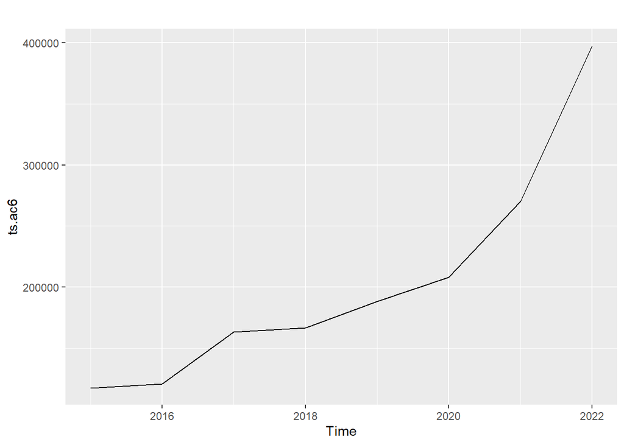

```r
ts.ac6<-ts(rev(b$ac6),start=2015,frequency=1)
autoplot(ts.ac6)
```

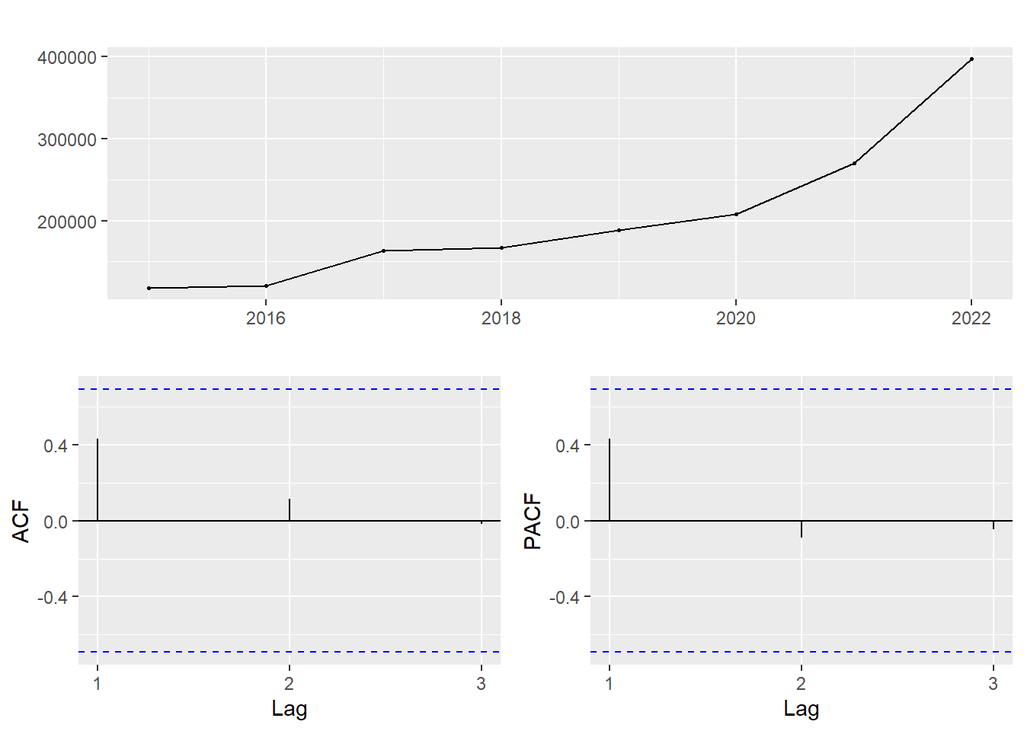

```r
ggtsdisplay(ts.ac6)
```

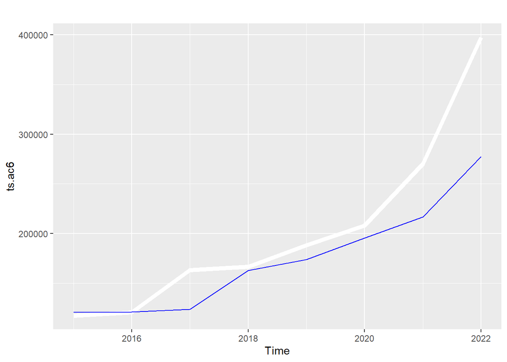

```r
fit6.holt<-holt(ts.ac6,alpha=0.8,beta=0.15)
autoplot(ts.ac6, color = "white", lwd = 2) +
   autolayer(fit6.holt$fitted, color = "blue")
```

```r
summary(fit6.holt)
```

```
##
## Forecast method: Holt's method
##
## Model Information:
## Holt's method
##
## Call:
##  holt(y = ts.ac6, alpha = 0.8, beta = 0.15)
##
##   Smoothing parameters:
##     alpha = 0.8
##     beta  = 0.15
##
##   Initial states:
##     l = 117566
##     b = 3288
##
##   sigma:  49037
## Error measures:
##                 ME  RMSE   MAE  MPE MAPE  MASE  ACF1
## Training set 30055 49037 30943 10.9 11.7 0.774 0.238
##
## Forecasts:
##      Point Forecast  Lo 80   Hi 80  Lo 95   Hi 95
## 2023         405580 342736  468424 309468  501692
## 2024         437721 351039  524402 305153  570289
## 2025         469861 358990  580733 300299  639424
## 2026         502002 366122  637882 294192  709813
## 2027         534143 372266  696020 286574  781712
## 2028         566284 377359  755208 277349  855219
## 2029         598424 381385  815464 266491  930358
## 2030         630565 384348  876782 254008 1007122
## 2031         662706 386263  939148 239924 1085488
## 2032         694847 387151 1002542 224267 1165426
```

##AC7: Autres actifs

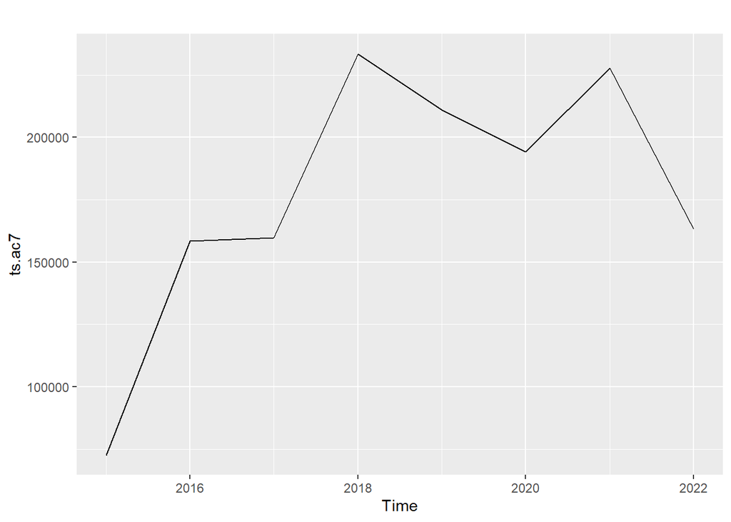

```r
ts.ac7<-ts(rev(b$ac7),start=2015,frequency=1)
autoplot(ts.ac7)
```

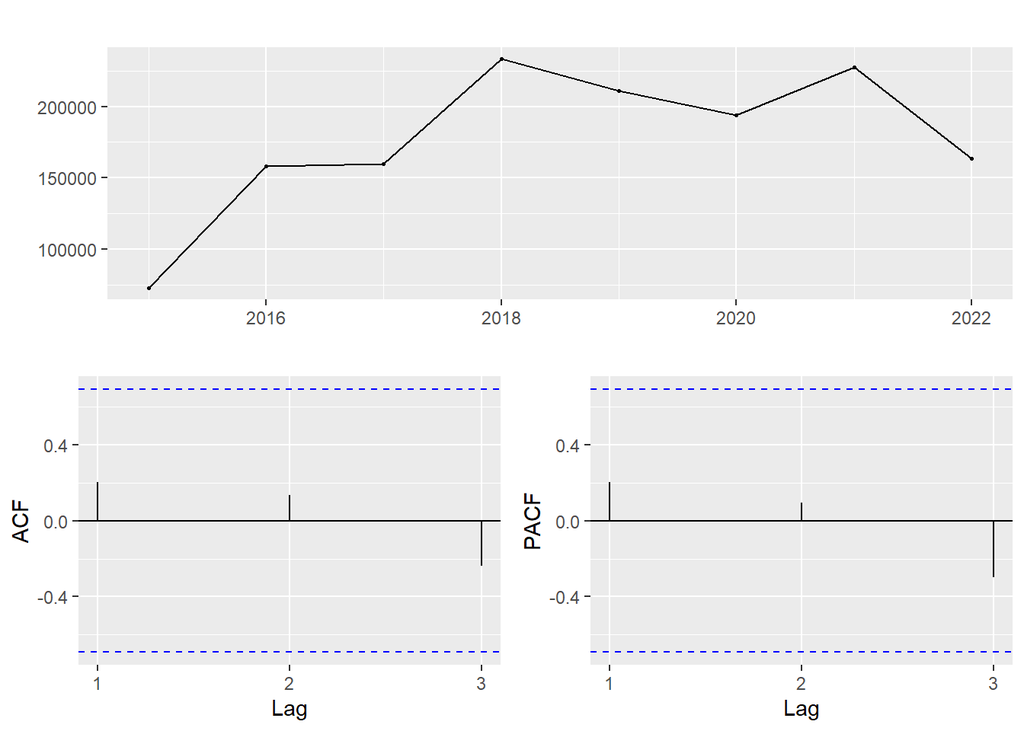

```r
ggtsdisplay(ts.ac7)
```

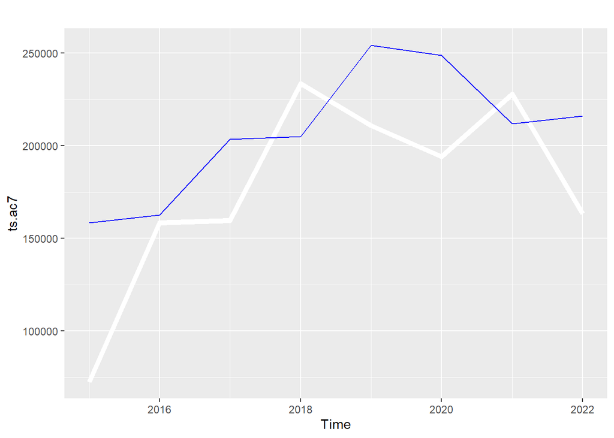

```r
fit7.holt<-holt(ts.ac7 )
autoplot(ts.ac7, color = "white", lwd = 2) +
   autolayer(fit7.holt$fitted, color = "blue")
```

```r
summary(fit7.holt)
```

```
##
## Forecast method: Holt's method
##
## Model Information:
## Holt's method
##
## Call:
##  holt(y = ts.ac7)
##
##   Smoothing parameters:
##     alpha = 0.4759
##     beta  = 1
##
##   Initial states:
##     l = 72601
##     b = 85797
##
##   sigma:  47481
## Error measures:
##                  ME  RMSE   MAE   MPE MAPE  MASE   ACF1
## Training set -30021 47481 41141 -26.3 31.1 0.965 -0.484
##
## Forecasts:
##      Point Forecast    Lo 80   Hi 80    Lo 95   Hi 95
## 2023         162460   101611  223310    69399  255522
## 2024         133955    25472  242438   -31955  299865
## 2025         105450   -80202  291102  -178481  389381
## 2026          76945  -204485  358375  -353465  507355
## 2027          48440  -343201  440080  -550523  647402
## 2028          19934  -494274  534142  -766479  806348
## 2029          -8571  -656407  639265  -999350  982209
## 2030         -37076  -828677  754525 -1247725 1173574
## 2031         -65581 -1010376  879214 -1510520 1379358
## 2032         -94086 -1200934 1012762 -1786864 1598692
```

#### PA1 et PA2:

- Les variables du passif; PA1: Banque Centrale et CCP et PA2: Dépôts et avoirs des établissements bancaires et financiers, sont analogues aux variables AC1 et AC2, sauf qu’elles reflètent les engagements financiers de la banque. En d’autres termes, ce que la banque est tenue de rembouser aux autres institutions.
- Il convient donc de les combiner en une variable somme **PA12**

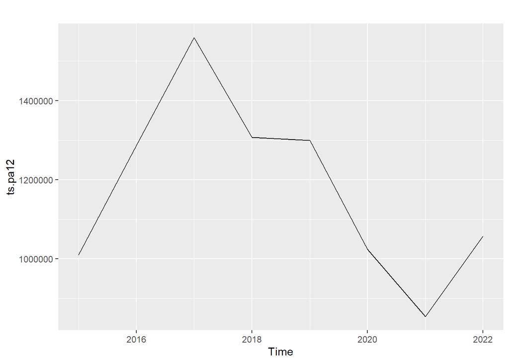

```r
ts.pa12<-ts(rev(b$pa1+b$pa2),start=2015,frequency=1)
autoplot(ts.pa12)
```

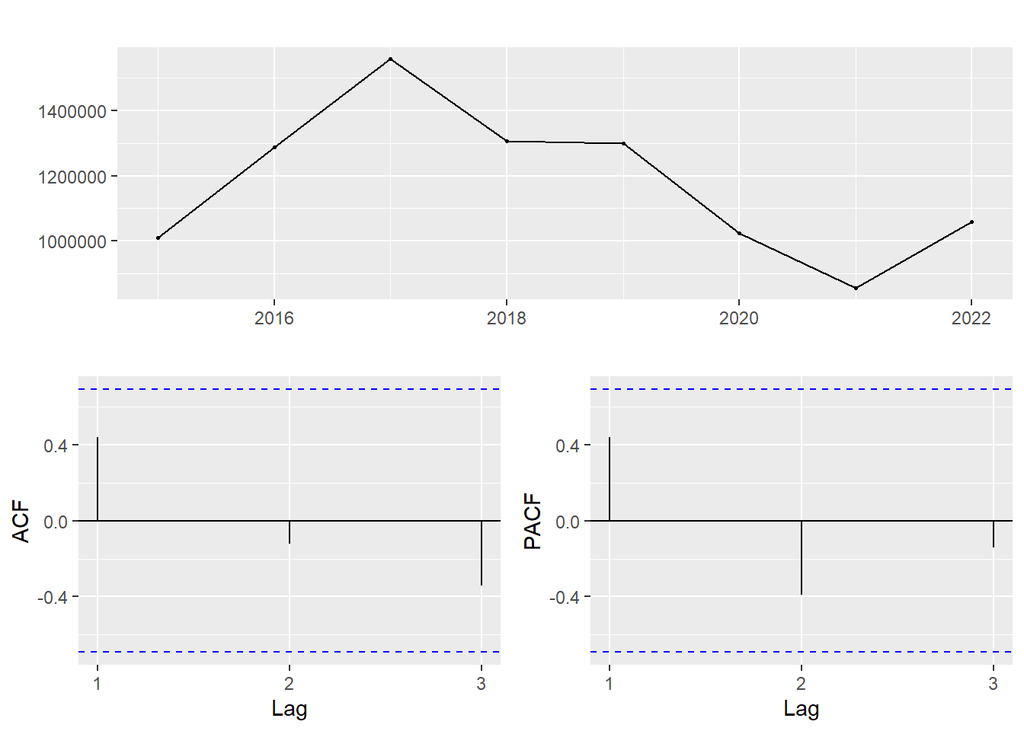

```r
ggtsdisplay(ts.pa12)
```

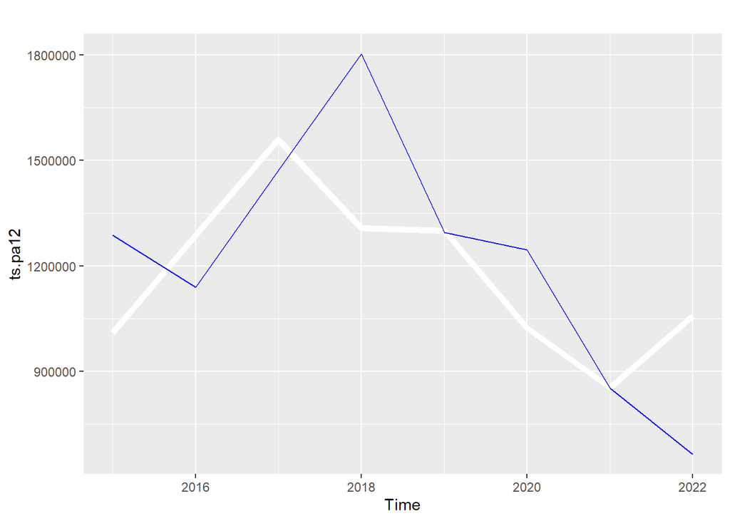

```r
fitp12.holt<-holt(ts.pa12, alpha = 0.9106, beta  = 0.68)
autoplot(ts.pa12, color = "white", lwd = 2) +
   autolayer(fitp12.holt$fitted, color = "blue")
```

```r
summary(fitp12.holt)
```

```
##
## Forecast method: Holt's method
##
## Model Information:
## Holt's method
##
## Call:
##  holt(y = ts.pa12, alpha = 0.9106, beta = 0.68)
##
##   Smoothing parameters:
##     alpha = 0.9106
##     beta  = 0.68
##
##   Initial states:
##     l = 1009424
##     b = 277638
##
##   sigma:  263976
## Error measures:
##                  ME   RMSE    MAE   MPE MAPE  MASE   ACF1
## Training set -45219 263976 203898 -4.05 17.7 0.978 -0.181
##
## Forecasts:
##      Point Forecast    Lo 80   Hi 80    Lo 95   Hi 95
## 2023        1076180   737881 1414480   558797 1593564
## 2024        1129821   494214 1765428   157744 2101898
## 2025        1183461   186446 2180476  -341341 2708264
## 2026        1237102  -173718 2647921  -920561 3394764
## 2027        1290742  -579808 3161292 -1570018 4151502
## 2028        1344382 -1027435 3716199 -2282999 4971763
## 2029        1398023 -1513322 4309367 -3054494 5850540
## 2030        1451663 -2034887 4938212 -3880554 6783880
## 2031        1505303 -2590018 5600625 -4757951 7768557
## 2032        1558944 -3176947 6294835 -5683977 8801864
```

# PA3: Dépôts et avoirs de la clientèle

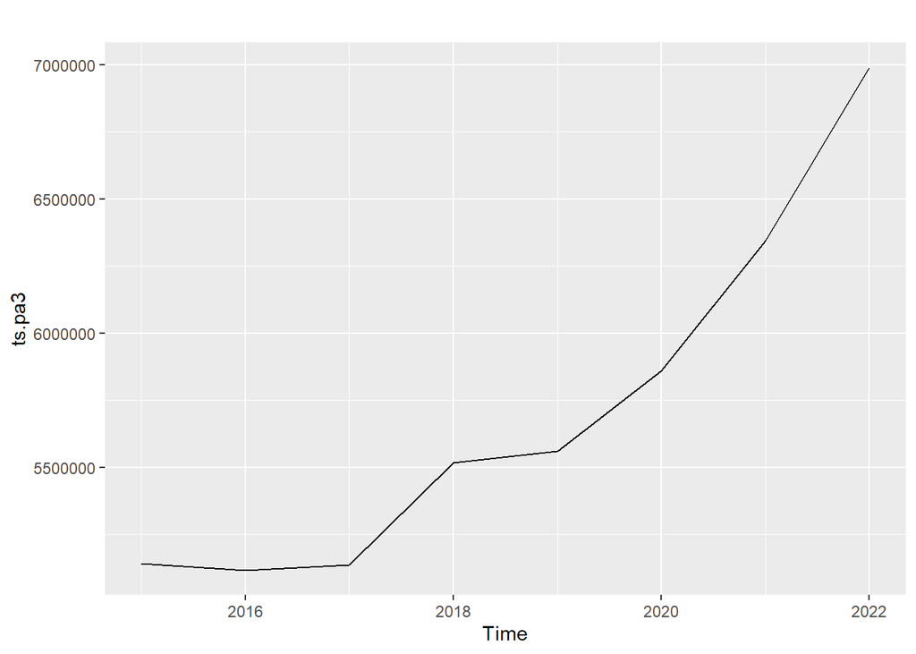

```r
ts.pa3<-ts(rev(b$pa3),start=2015,frequency=1)
autoplot(ts.pa3)
```

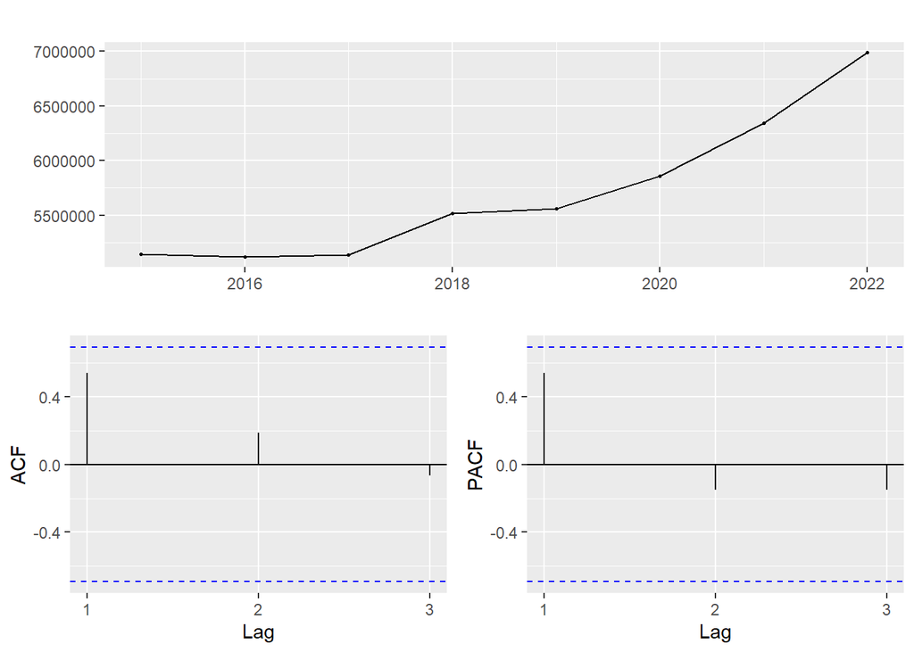

```r
ggtsdisplay(ts.pa3)
```

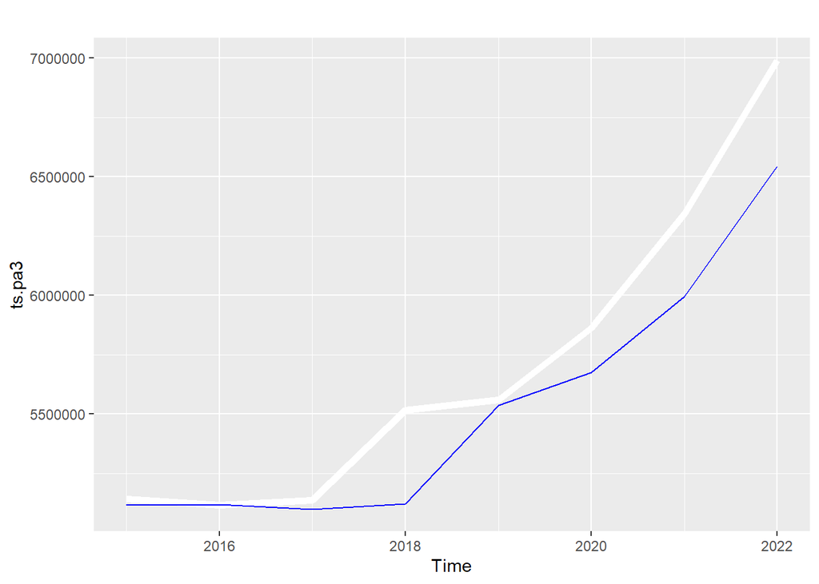

```r
fitp3.holt<-holt(ts.pa3,alpha = 0.7612, beta  = 0.4)
autoplot(ts.pa3, color = "white", lwd = 2) +
   autolayer(fitp3.holt$fitted, color = "blue")
```

```r
summary(fitp3.holt)
```

```
##
## Forecast method: Holt's method
##
## Model Information:
## Holt's method
##
## Call:
##  holt(y = ts.pa3, alpha = 0.7612, beta = 0.4)
##
##   Smoothing parameters:
##     alpha = 0.7612
##     beta  = 0.4
##
##   Initial states:
##     l = 5142391
##     b = -25453
##
##   sigma:  253782
## Error measures:
##                  ME   RMSE    MAE  MPE MAPE  MASE  ACF1
## Training set 182862 253782 183280 2.98 2.99 0.675 0.142
##
## Forecasts:
##      Point Forecast   Lo 80    Hi 80   Lo 95    Hi 95
## 2023        7304169 6978935  7629403 6806766  7801572
## 2024        7724138 7225735  8222541 6961896  8486380
## 2025        8144107 7432615  8855600 7055973  9232241
## 2026        8564076 7608527  9519625 7102690 10025462
## 2027        8984045 7758154 10209937 7109206 10858885
## 2028        9404014 7884383 10923646 7079938 11728090
## 2029        9823983 7989227 11658740 7017965 12630002
## 2030       10243953 8074202 12413703 6925606 13562299
## 2031       10663922 8140516 13187328 6804705 14523138
## 2032       11083891 8189159 13978622 6656781 15511000
```

# PA4: Emprunts et Ressources spéciales

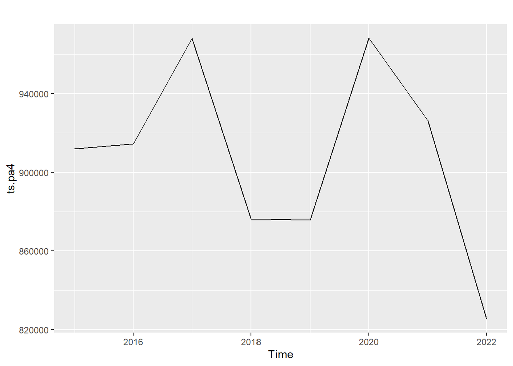

```r
ts.pa4<-ts(rev(b$pa4),start=2015,frequency=1)
autoplot(ts.pa4)
```

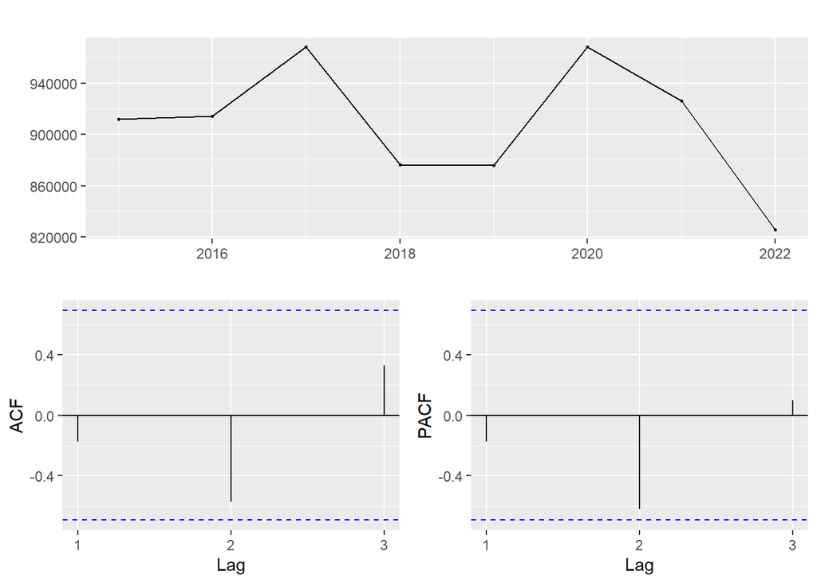

```r
ggtsdisplay(ts.pa4)
```

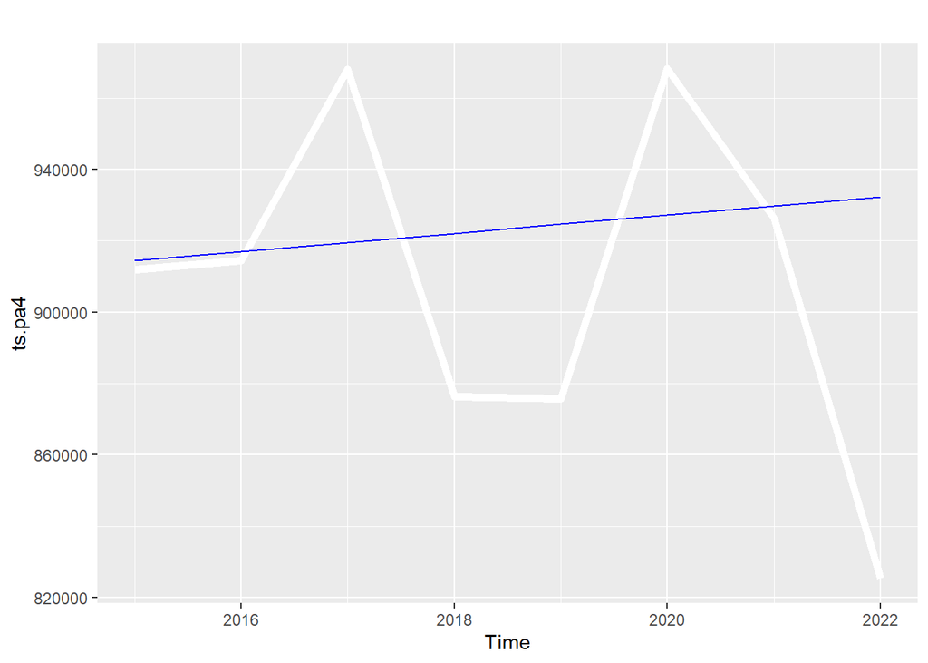

```r
fitp4.holt<-holt(ts.pa4)
autoplot(ts.pa4, color = "white", lwd = 2) +
   autolayer(fitp4.holt$fitted, color = "blue")
```

```r
summary(fitp4.holt)
```

```
##
## Forecast method: Holt's method
##
## Model Information:
## Holt's method
##
## Call:
##  holt(y = ts.pa4)
##
##   Smoothing parameters:
##     alpha = 0
##     beta  = 0
##
##   Initial states:
##     l = 911881
##     b = 2551
##
##   sigma:  49954
## Error measures:
##                  ME  RMSE   MAE   MPE MAPE  MASE   ACF1
## Training set -15051 49954 37470 -1.93 4.24 0.683 -0.126
##
## Forecasts:
##      Point Forecast  Lo 80   Hi 80  Lo 95   Hi 95
## 2023         934840 870821  998859 836931 1032749
## 2024         937391 873372 1001410 839482 1035300
## 2025         939942 875923 1003961 842033 1037851
## 2026         942493 878474 1006512 844584 1040402
## 2027         945044 881025 1009063 847135 1042953
## 2028         947595 883576 1011614 849686 1045504
## 2029         950146 886127 1014165 852237 1048055
## 2030         952697 888678 1016716 854788 1050606
## 2031         955248 891229 1019267 857339 1053157
## 2032         957799 893780 1021818 859890 1055708
```

# PA5: Autres passifs

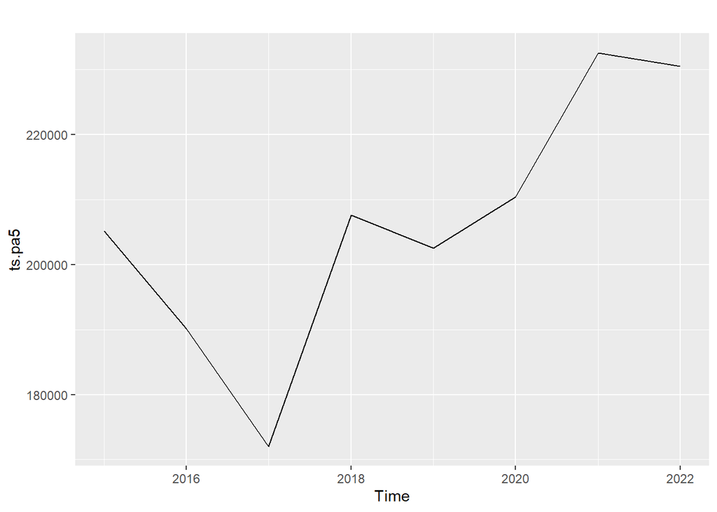

```r
ts.pa5<-ts(rev(b$pa5),start=2015,frequency=1)
autoplot(ts.pa5)
```

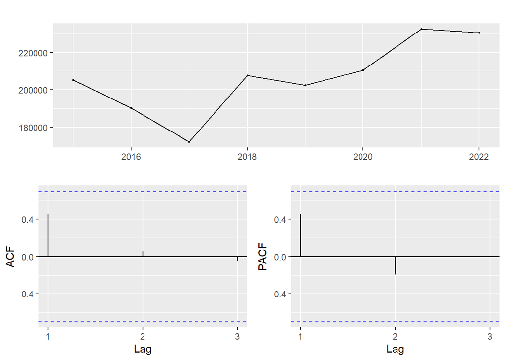

```r
ggtsdisplay(ts.pa5)
```

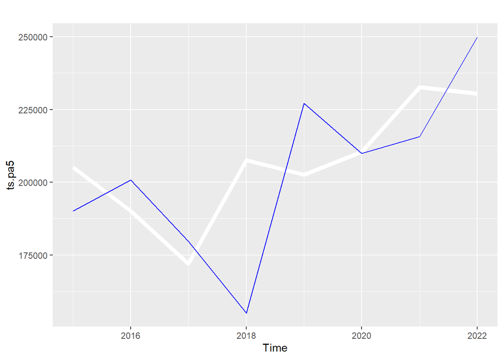

```r
fitp5.holt<-holt(ts.pa5,alpha=0.9,beta=0.9)
autoplot(ts.pa5, color = "white", lwd = 2) +
   autolayer(fitp5.holt$fitted, color = "blue")
```

```r
summary(fitp5.holt)
```

```
##
## Forecast method: Holt's method
##
## Model Information:
## Holt's method
##
## Call:
##  holt(y = ts.pa5, alpha = 0.9, beta = 0.9)
##
##   Smoothing parameters:
##     alpha = 0.9
##     beta  = 0.9
##
##   Initial states:
##     l = 205186
##     b = -15032
##
##   sigma:  23511
## Error measures:
##                ME  RMSE   MAE  MPE MAPE MASE   ACF1
## Training set 2830 23511 18417 1.19 8.85 1.22 -0.502
##
## Forecasts:
##      Point Forecast   Lo 80  Hi 80   Lo 95   Hi 95
## 2023         235781  205651 265911  189701  281861
## 2024         239090  177049 301132  144206  333975
## 2025         242399  140090 344708   85931  398868
## 2026         245708   96602 394814   17670  473746
## 2027         249017   47483 450551  -59203  557237
## 2028         252326   -6688 511340 -143801  648453
## 2029         255635  -65488 576757 -235479  746749
## 2030         258944 -128588 646476 -333735  851623
## 2031         262253 -195725 720230 -438163  962669
## 2032         265562 -266676 797799 -548426 1079549
```

# CP1: Capital

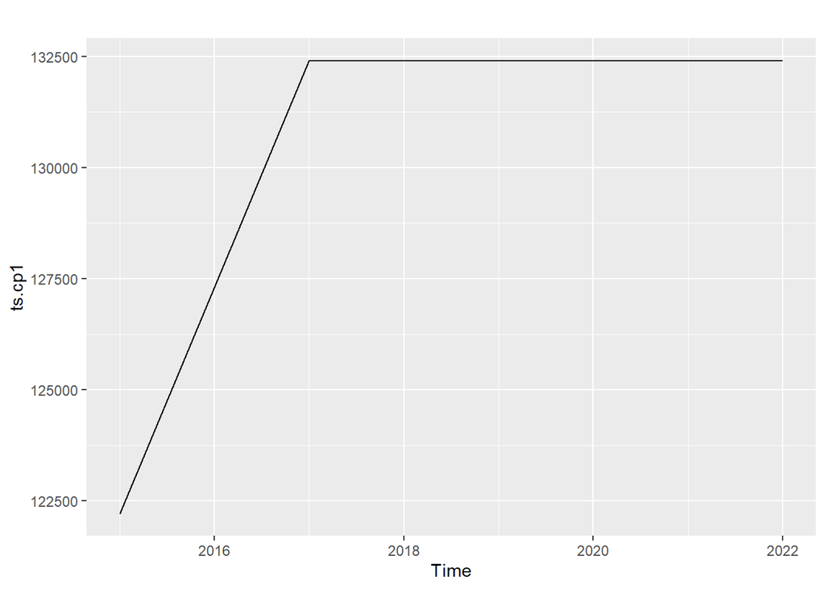

```r
ts.cp1<-ts(rev(b$cp1),start=2015,frequency=1)
autoplot(ts.cp1)
```

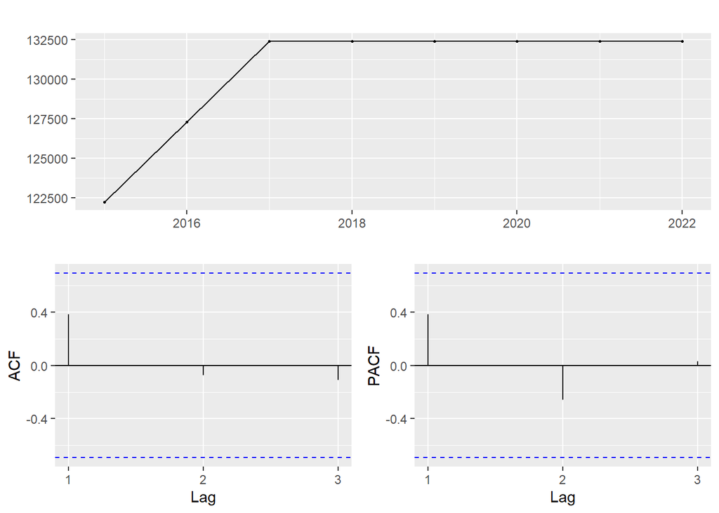

```r
ggtsdisplay(ts.cp1)
```

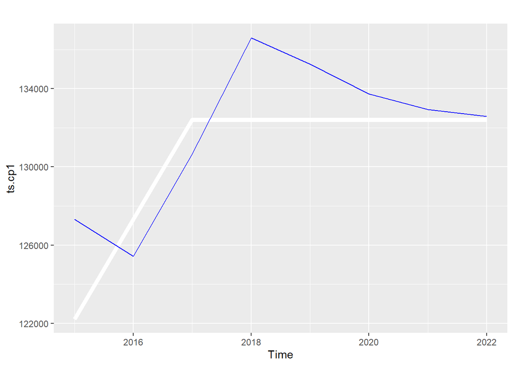

```r
fitcp1.holt<-holt(ts.cp1)
autoplot(ts.cp1, color = "white", lwd = 2) +
   autolayer(fitcp1.holt$fitted, color = "blue")
```

```r
summary(fitcp1.holt)
```

```
##
## Forecast method: Holt's method
##
## Model Information:
## Holt's method
##
## Call:
##  holt(y = ts.cp1)
##
##   Smoothing parameters:
##     alpha = 0.8901
##     beta  = 0.5391
##
##   Initial states:
##     l = 122220
##     b = 5093
##
##   sigma:  2745
## Error measures:
##                 ME RMSE  MAE   MPE MAPE MASE   ACF1
## Training set -1317 2745 2224 -1.03 1.73 1.53 -0.125
##
## Forecasts:
##      Point Forecast  Lo 80  Hi 80  Lo 95  Hi 95
## 2023         132464 128945 135982 127083 137844
## 2024         132502 126365 138639 123116 141887
## 2025         132540 123287 141793 118389 146691
## 2026         132578 119794 145363 113027 152130
## 2027         132617 115934 149299 107102 158131
## 2028         132655 111739 153570 100667 164642
## 2029         132693 107236 158150  93760 171626
## 2030         132731 102445 163018  86412 179051
## 2031         132770  97381 168158  78648 186892
## 2032         132808  92059 173557  70488 195128
```

## CP2: Réserves.

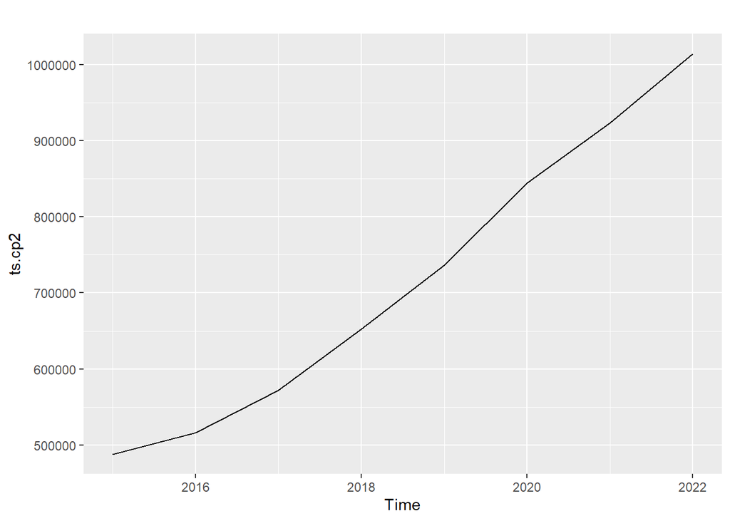

```r
ts.cp2<-ts(rev(b$cp2),start=2015,frequency=1)
autoplot(ts.cp2)
```

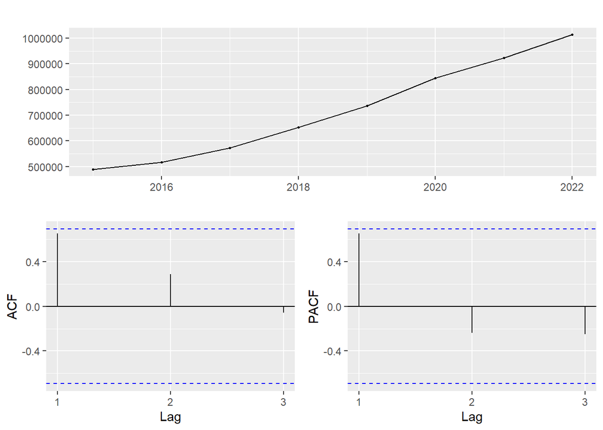

```r
ggtsdisplay(ts.cp2)
```

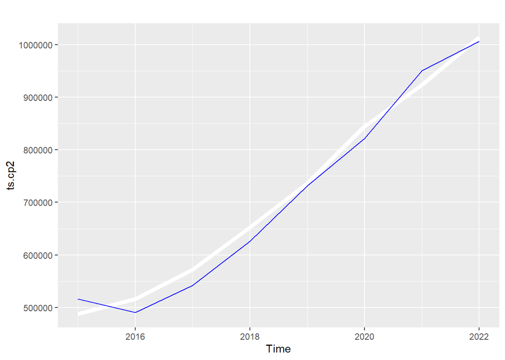

```r
fitcp2.holt<-holt(ts.cp2)
autoplot(ts.cp2, color = "white", lwd = 2) +
   autolayer(fitcp2.holt$fitted, color = "blue")
```

```r
summary(fitcp2.holt)
```

```
##
## Forecast method: Holt's method
##
## Model Information:
## Holt's method
##
## Call:
##  holt(y = ts.cp2)
##
##   Smoothing parameters:
##     alpha = 0.9599
##     beta  = 1
##
##   Initial states:
##     l = 488066
##     b = 28519
##
##   sigma:  23565
## Error measures:
##                ME  RMSE   MAE  MPE MAPE  MASE   ACF1
## Training set 7916 23565 21744 1.23 3.41 0.289 -0.126
##
## Forecasts:
##      Point Forecast   Lo 80   Hi 80   Lo 95   Hi 95
## 2023        1103439 1073240 1133639 1057254 1149625
## 2024        1192745 1126297 1259192 1091122 1294367
## 2025        1282050 1170671 1393430 1111710 1452390
## 2026        1371355 1207934 1534776 1121424 1621286
## 2027        1460661 1238980 1682341 1121629 1799692
## 2028        1549966 1264419 1835513 1113259 1986672
## 2029        1639271 1284708 1993834 1097014 2181528
## 2030        1728576 1300208 2156945 1073444 2383709
## 2031        1817882 1311211 2324552 1042996 2592767
## 2032        1907187 1317963 2496411 1006046 2808328
```

# CP5: Résultats reportés

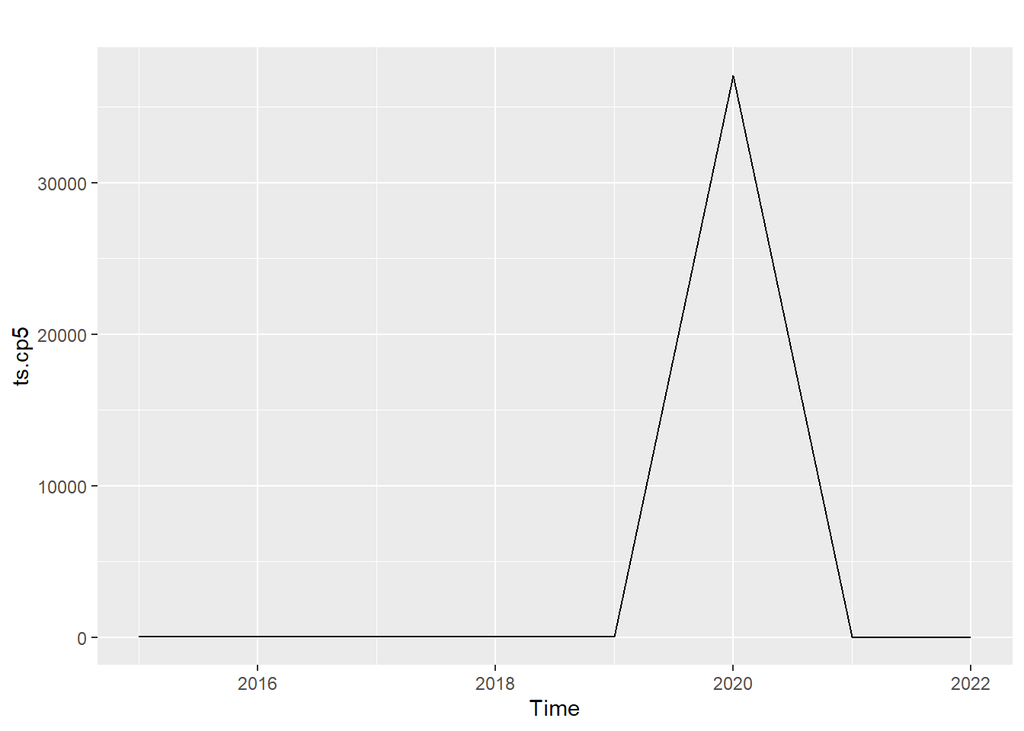

```r
ts.cp5<-ts(rev(b$cp5),start=2015,frequency=1)
autoplot(ts.cp5)
```

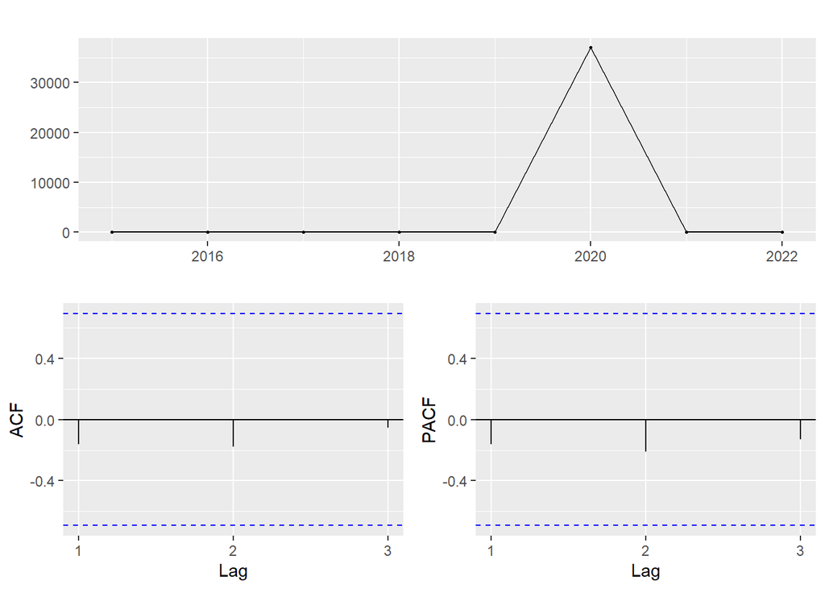

```r
ggtsdisplay(ts.cp5)
```

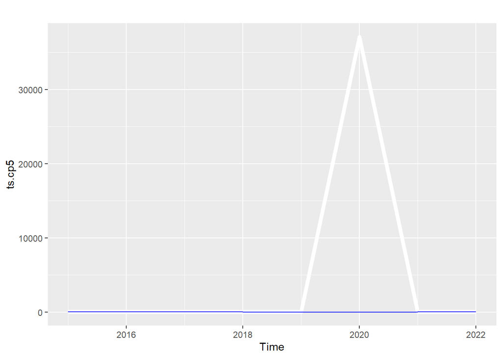

```r
fitcp5.holt<-holt(ts.cp5)
autoplot(ts.cp5, color = "white", lwd = 2) +
   autolayer(fitcp5.holt$fitted, color = "blue")
```

```r
summary(fitcp5.holt)
```

```
##
## Forecast method: Holt's method
##
## Model Information:
## Holt's method
##
## Call:
##  holt(y = ts.cp5)
##
##   Smoothing parameters:
##     alpha = 0.0002
##     beta  = 0
##
##   Initial states:
##     l = 5
##     b = -1
##
##   sigma:  13114
## Error measures:
##                ME  RMSE  MAE   MPE MAPE  MASE  ACF1
## Training set 4640 13114 4642 -17.7  114 0.438 -0.16
##
## Forecasts:
##      Point Forecast  Lo 80 Hi 80  Lo 95 Hi 95
## 2023          4.884 -16801 16811 -25698 25708
## 2024          3.884 -16802 16810 -25699 25707
## 2025          2.884 -16803 16809 -25700 25706
## 2026          1.884 -16804 16808 -25701 25705
## 2027          0.884 -16805 16807 -25702 25704
## 2028         -0.116 -16806 16806 -25703 25703
## 2029         -1.116 -16807 16805 -25704 25702
## 2030         -2.116 -16808 16804 -25705 25701
## 2031         -3.116 -16809 16803 -25706 25700
## 2032         -4.116 -16810 16802 -25707 25699
```

# CP6: Résultat de l’exercice

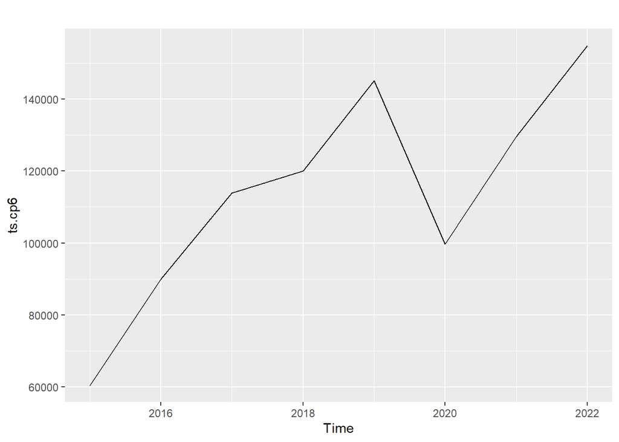

```r
ts.cp6<-ts(rev(b$cp6),start=2015,frequency=1)
autoplot(ts.cp6)
```

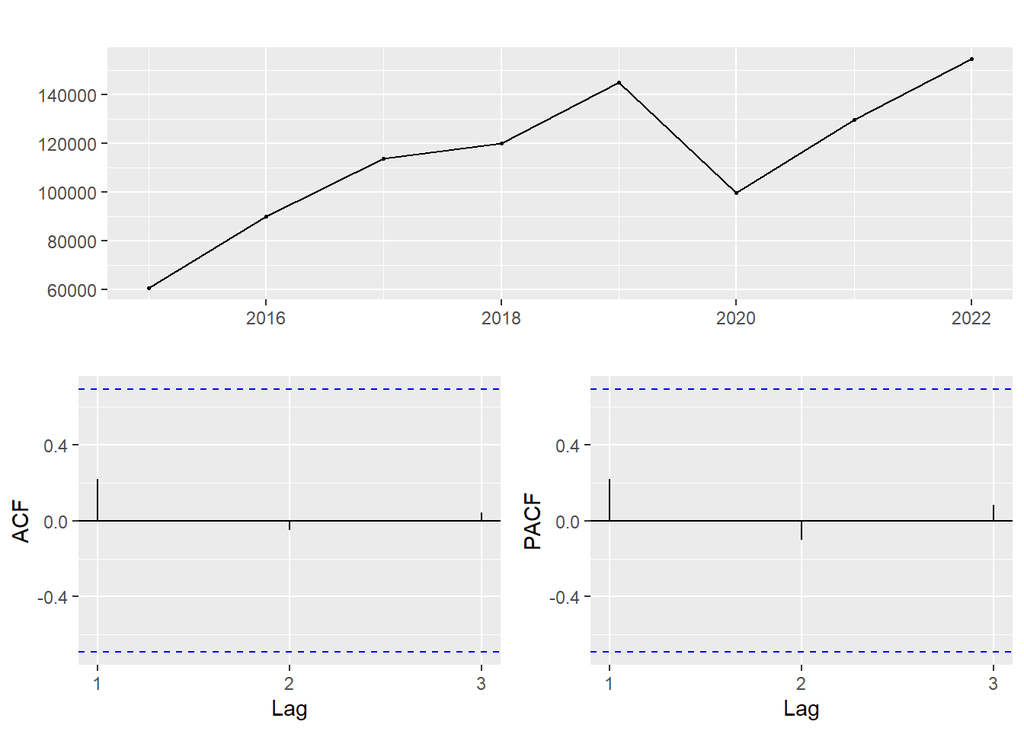

```r
ggtsdisplay(ts.cp6)
```

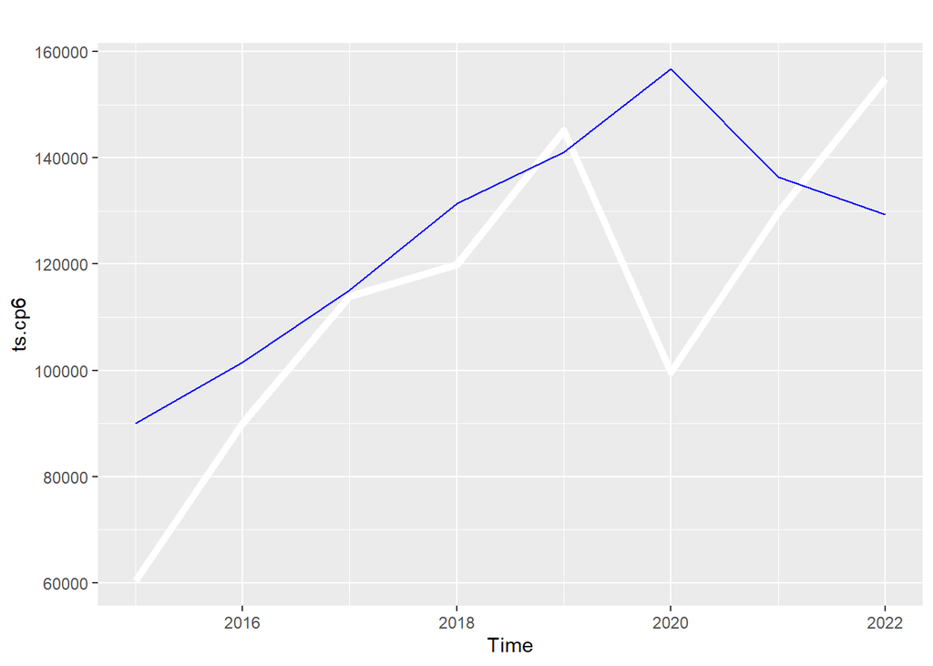

```r
fitcp6.holt<-holt(ts.cp6)
autoplot(ts.cp6, color = "white", lwd = 2) +
   autolayer(fitcp6.holt$fitted, color = "blue")
```

```r
summary(fitcp6.holt)
```

```
##
## Forecast method: Holt's method
##
## Model Information:
## Holt's method
##
## Call:
##  holt(y = ts.cp6)
##
##   Smoothing parameters:
##     alpha = 0.3051
##     beta  = 1
##
##   Initial states:
##     l = 60458
##     b = 29548
##
##   sigma:  25288
## Error measures:
##                  ME  RMSE   MAE   MPE MAPE  MASE   ACF1
## Training set -10969 25288 18385 -14.4 19.2 0.694 -0.178
##
## Forecasts:
##      Point Forecast   Lo 80  Hi 80   Lo 95   Hi 95
## 2023         139873  107465 172281   90310  189437
## 2024         142649   89366 195933   61159  224139
## 2025         145425   53666 237183    5092  285758
## 2026         148201    7160 289241  -67502  363903
## 2027         150976  -47412 349365 -152432  454385
## 2028         153752 -108767 416272 -247737  555241
## 2029         156528 -176142 489198 -352246  665303
## 2030         159304 -249005 567613 -465151  783759
## 2031         162080 -326958 651118 -585839  909999
## 2032         164855 -409684 739395 -713827 1043538
```

# CP4: Autres capitaux propres

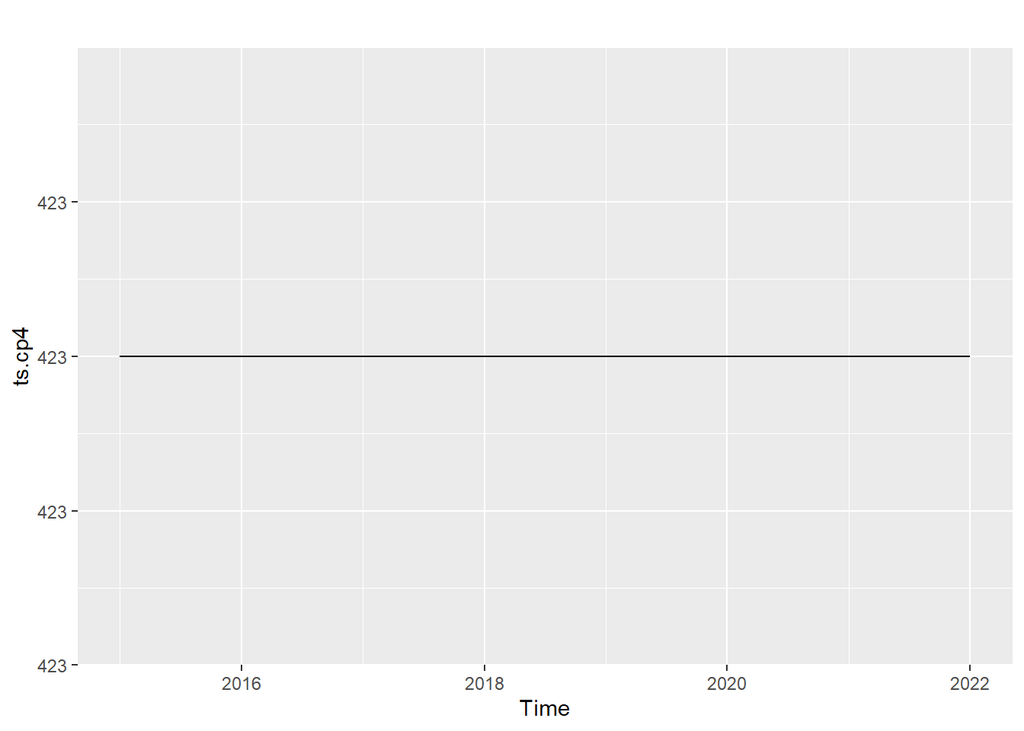

```r
ts.cp4<-ts(rev(b$cp4),start=2015,frequency=1)
autoplot(ts.cp4)
```

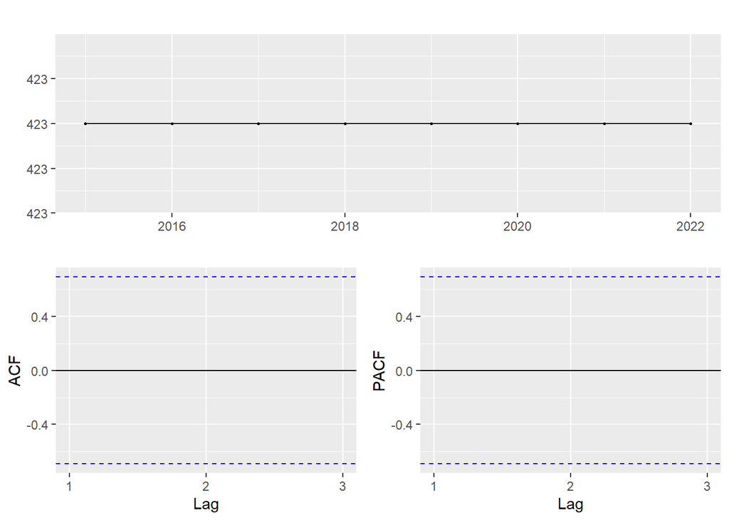

```r
ggtsdisplay(ts.cp4)
```

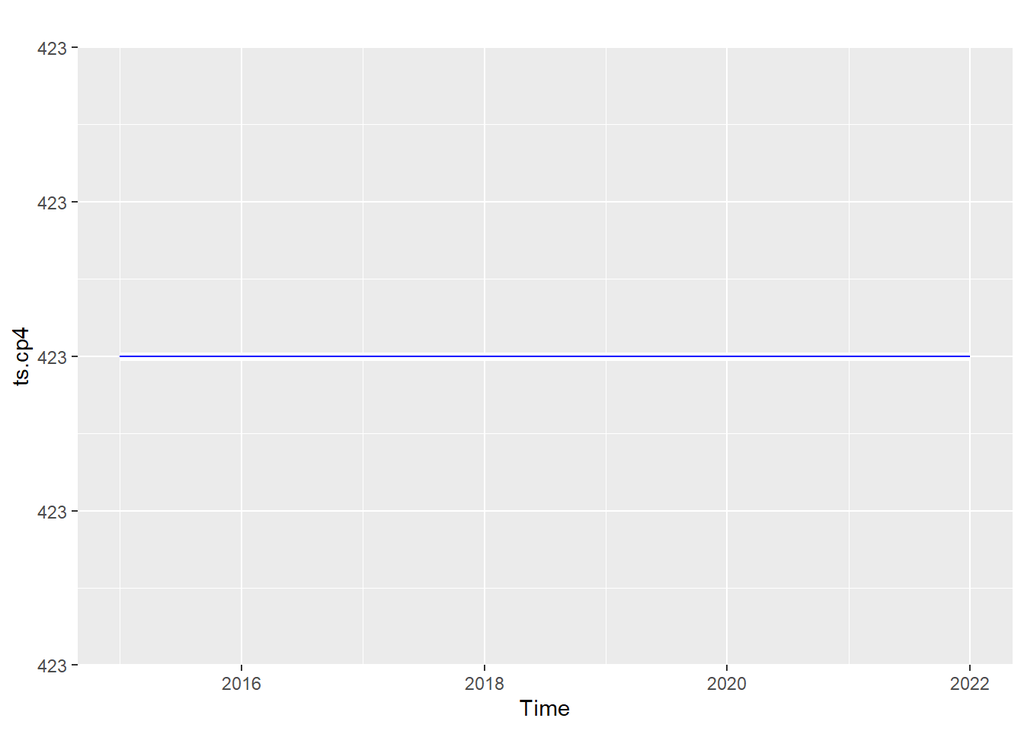

```r
fitcp4.holt<-holt(ts.cp4)
autoplot(ts.cp4, color = "white", lwd = 2) +
   autolayer(fitcp4.holt$fitted, color = "blue")
```

```r
summary(fitcp4.holt)
```

```
##
## Forecast method: Holt's method
##
## Model Information:
## Holt's method
##
## Call:
##  holt(y = ts.cp4)
##
##   Smoothing parameters:
##     alpha = 0.2
##     beta  = 0.02
##
##   Initial states:
##     l = 423
##     b = 0
##
##   sigma:  0
## Error measures:
##                               ME            RMSE                MAE
## Training set -0.0000000000000924 0.0000000000001 0.0000000000000924
##                              MPE               MAPE MASE  ACF1
## Training set -0.0000000000000218 0.0000000000000218  Inf 0.383
##
## Forecasts:
##      Point Forecast Lo 80 Hi 80 Lo 95 Hi 95
## 2023            423   423   423   423   423
## 2024            423   423   423   423   423
## 2025            423   423   423   423   423
## 2026            423   423   423   423   423
## 2027            423   423   423   423   423
## 2028            423   423   423   423   423
## 2029            423   423   423   423   423
## 2030            423   423   423   423   423
## 2031            423   423   423   423   423
## 2032            423   423   423   423   423
```

# Bilan annuel simulé

Balance Sheet Comparison: Actual, Fitted, and Predicted Values

[output not shown]

Table continues below

|  |  | fit15 |  | fit16 |
| --- | --- | --- | --- | --- |
| **AC12: Caisse et avoirs auprès de la BCT, CCP et TGT + Créances sur les établissements bancaires et financiers** | 301654 | 277550 | 277550 | 277550 |
| **AC3: Créances sur la clientèle** | 5971463 | 5893685 | 5893685 | 5948091 |
| **AC45: Portefeuille-titres commercial et Portefeuille d’investissement** | 1476770 | 1792430 | 1792430 | 1741390 |
| **AC6: Valeurs immobilisées** | 117566 | 120854 | 120854 | 121117 |
| **AC7: Autres actifs** | 72601 | 158398 | 158398 | 162528 |
| **Total actifs** | 7940054 | 8242917 | 8242917 | 8250676 |
| **PA12: Banque Centrale et CCP et Dépôts et avoirs des établissements bancaires et financiers** | 1009424 | 1287062 | 1287062 | 1139967 |
| **PA3: Dépôts et avoirs de la clientèle** | 5142391 | 5116938 | 5116938 | 5118610 |
| **PA4: Emprunts et Ressources spéciales** | 911881 | 914432 | 914432 | 916983 |
| **PA5: Autres passifs** | 205186 | 190154 | 190154 | 200827 |
| **Total passifs** | 7268882 | 7508586 | 7508586 | 7376387 |
| **CP1: Capital** | 122220 | 127313 | 127313 | 125428 |
| **CP2: Réserves** | 488066 | 516585 | 516585 | 490352 |
| **CP4: Autres capitaux propres** | 423 | 423 | 423 | 423 |
| **CP5: Résultats reportés** | 5 | 4 | 4 | 3 |
| **CP6: Résultat de l’exercice** | 60458 | 90006 | 90006 | 101525 |
| **Total capitaux propres** | 671172 | 734331 | 734331 | 717732 |
| **Total capitaux propres et passifs** | 7940054 | 8242917 | 8242917 | 8094118 |

Table continues below

|  |  | fit17 |  | fit18 |
| --- | --- | --- | --- | --- |
| **AC12: Caisse et avoirs auprès de la BCT, CCP et TGT + Créances sur les établissements bancaires et financiers** | 367277 | 253446 | 585581 | 343173 |
| **AC3: Créances sur la clientèle** | 6073730 | 5843942 | 5929248 | 6176550 |
| **AC45: Portefeuille-titres commercial et Portefeuille d’investissement** | 1892208 | 2000794 | 1897993 | 2093445 |
| **AC6: Valeurs immobilisées** | 163219 | 123768 | 166778 | 162925 |
| **AC7: Autres actifs** | 159764 | 203560 | 233528 | 204870 |
| **Total actifs** | 8656198 | 8425511 | 8813128 | 8980963 |
| **PA12: Banque Centrale et CCP et Dépôts et avoirs des établissements bancaires et financiers** | 1559931 | 1470716 | 1307122 | 1804002 |
| **PA3: Dépôts et avoirs de la clientèle** | 5137206 | 5099125 | 5516889 | 5121495 |
| **PA4: Emprunts et Ressources spéciales** | 968065 | 919534 | 876255 | 922085 |
| **PA5: Autres passifs** | 172039 | 179720 | 207581 | 155084 |
| **Total passifs** | 7837241 | 7669096 | 7907847 | 8002667 |
| **CP1: Capital** | 132405 | 130659 | 132405 | 136604 |
| **CP2: Réserves** | 572213 | 541858 | 652478 | 626459 |
| **CP4: Autres capitaux propres** | 423 | 423 | 423 | 423 |
| **CP5: Résultats reportés** | 5 | 2 | 5 | 1.001 |
| **CP6: Résultat de l’exercice** | 113911 | 115030 | 119970 | 131367 |
| **Total capitaux propres** | 818957 | 787973 | 905281 | 894854 |
| **Total capitaux propres et passifs** | 8656198 | 8457069 | 8813128 | 8897521 |

Table continues below

|  |  | fit19 |  | fit20 |
| --- | --- | --- | --- | --- |
| **AC12: Caisse et avoirs auprès de la BCT, CCP et TGT + Créances sur les établissements bancaires et financiers** | 1029846 | 561477 | 657970 | 1005742 |
| **AC3: Créances sur la clientèle** | 5727900 | 5893605 | 6003059 | 5539189 |
| **AC45: Portefeuille-titres commercial et Portefeuille d’investissement** | 1794738 | 2045436 | 2114255 | 1861702 |
| **AC6: Valeurs immobilisées** | 188436 | 174066 | 208163 | 195345 |
| **AC7: Autres actifs** | 210993 | 254302 | 194124 | 248871 |
| **Total actifs** | 8951913 | 8928886 | 9177571 | 8850849 |
| **PA12: Banque Centrale et CCP et Dépôts et avoirs des établissements bancaires et financiers** | 1299523 | 1295918 | 1023860 | 1245808 |
| **PA3: Dépôts et avoirs de la clientèle** | 5559635 | 5536241 | 5861002 | 5674944 |
| **PA4: Emprunts et Ressources spéciales** | 875676 | 924636 | 968332 | 927187 |
| **PA5: Autres passifs** | 202531 | 227131 | 210426 | 209865 |
| **Total passifs** | 7937365 | 7983926 | 8063620 | 8057803 |
| **CP1: Capital** | 132405 | 135242 | 132405 | 133731 |
| **CP2: Réserves** | 736529 | 731874 | 844373 | 821250 |
| **CP4: Autres capitaux propres** | 423 | 423 | 423 | 423 |
| **CP5: Résultats reportés** | 26 | 0.002153 | 37091 | 0.9916 |
| **CP6: Résultat de l’exercice** | 145165 | 141091 | 99659 | 156778 |
| **Total capitaux propres** | 1014548 | 1008630 | 1113951 | 1112182 |
| **Total capitaux propres et passifs** | 8951913 | 8992556 | 9177571 | 9169986 |

Table continues below

|  |  | fit21 |  | fit22 |
| --- | --- | --- | --- | --- |
| **AC12: Caisse et avoirs auprès de la BCT, CCP et TGT + Créances sur les établissements bancaires et financiers** | 529335 | 633866 | 587954 | 505231 |
| **AC3: Créances sur la clientèle** | 6245664 | 6113930 | 6889784 | 6518379 |
| **AC45: Portefeuille-titres commercial et Portefeuille d’investissement** | 2270398 | 2170822 | 2368299 | 2394678 |
| **AC6: Valeurs immobilisées** | 270250 | 216920 | 397473 | 277305 |
| **AC7: Autres actifs** | 227763 | 211940 | 163260 | 216126 |
| **Total actifs** | 9543410 | 9347479 | 10406770 | 9911719 |
| **PA12: Banque Centrale et CCP et Dépôts et avoirs des établissements bancaires et financiers** | 854460 | 852877 | 1057694 | 664474 |
| **PA3: Dépôts et avoirs de la clientèle** | 6343825 | 5994118 | 6990819 | 6544340 |
| **PA4: Emprunts et Ressources spéciales** | 926283 | 929738 | 825551 | 932289 |
| **PA5: Autres passifs** | 232599 | 215698 | 230533 | 249927 |
| **Total passifs** | 8357167 | 7992431 | 9104597 | 8391030 |
| **CP1: Capital** | 132405 | 132929 | 132405 | 132589 |
| **CP2: Réserves** | 923755 | 950550 | 1014465 | 1006212 |
| **CP4: Autres capitaux propres** | 423 | 423 | 423 | 423 |
| **CP5: Résultats reportés** | 5 | 6.885 | 1 | 5.885 |
| **CP6: Résultat de l’exercice** | 129655 | 136371 | 154879 | 129291 |
| **Total capitaux propres** | 1186243 | 1220279 | 1302173 | 1268521 |
| **Total capitaux propres et passifs** | 9543410 | 9212710 | 10406770 | 9659551 |

Table continues below

[output not shown]

|  | fit27 |
| --- | --- |
| **AC12: Caisse et avoirs auprès de la BCT, CCP et TGT + Créances sur les établissements bancaires et financiers** | 467434 |
| **AC3: Créances sur la clientèle** | 9874531 |
| **AC45: Portefeuille-titres commercial et Portefeuille d’investissement** | 3048556 |
| **AC6: Valeurs immobilisées** | 534143 |
| **AC7: Autres actifs** | 48440 |
| **Total actifs** | 13973103 |
| **PA12: Banque Centrale et CCP et Dépôts et avoirs des établissements bancaires et financiers** | 1290742 |
| **PA3: Dépôts et avoirs de la clientèle** | 8984045 |
| **PA4: Emprunts et Ressources spéciales** | 945044 |
| **PA5: Autres passifs** | 249017 |
| **Total passifs** | 11468848 |
| **CP1: Capital** | 132617 |
| **CP2: Réserves** | 1460661 |
| **CP4: Autres capitaux propres** | 423 |
| **CP5: Résultats reportés** | 0.8837 |
| **CP6: Résultat de l’exercice** | 150976 |
| **Total capitaux propres** | 1744678 |
| **Total capitaux propres et passifs** | 13213526 |

## Discussion

```r
error<-c()
for (i in seq(from = 1, to = 15, by = 2)){
  actual<-c(bs[,i])
  predicted<-c(bs[,i+1])
  relative_error <- abs(actual - predicted) / actual
  error<-c(error,mean(relative_error))
}
print(error)
```

```
## [1] 0.1591 0.0412 0.1036 0.1378 0.1202 0.1673 0.0695 0.3758
```

```r
 mean(error)
```

```
## [1] 0.147
```

#### L’ajustement qu’on a effectué prsente une erreur relative d’environ 14.7%. Ce qui peut être justifié par :

- Le fait que le modèle ajusté ne tient pas compte des corrélations entre les variables du bilan.
- Le très petit nombre de données a affecté la qualité du modèle.
- Cette première tentative de simulation a permis une exploration plus approfondie des variables du bilan, tant sur le plan quantitatif que qualitatif. Grâce à cela, nous avons pu simplifier le bilan en combinant plusieurs variables.
- Dans ce qui suit nous allons essayer de diminuer l’erreur en aumgmentant le nombre d’observations (bilan semestriel).